# DEFENSIVE TRAITS H.murinum SIBECOL 2025

### H.murinum - PERIODO DE FLORACIÓN

**periodo_flor ~ trat + clip + trat:clip**  
n = **7**

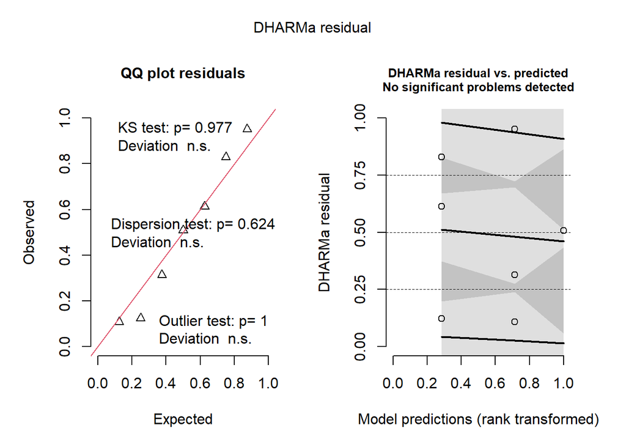

##### HOperiodo_flor Post-hoc Comparisons with Tukeys HSD

| contrast | trat | estimate | SE | df | z.ratio | p.value |
| --- | --- | --- | --- | --- | --- | --- |
| no - yes | ex | NA | NA | NA | NA | NA |
| no - yes | gra | -0.1857171 | 0.1975367 | Inf | -0.9401653 | 0.3471328 |

| contrast | clip | estimate | SE | df | z.ratio | p.value |
| --- | --- | --- | --- | --- | --- | --- |
| ex - gra | no | NA | NA | NA | NA | NA |
| ex - gra | yes | 0.3169116 | 0.2394014 | Inf | 1.323767 | 0.1855805 |

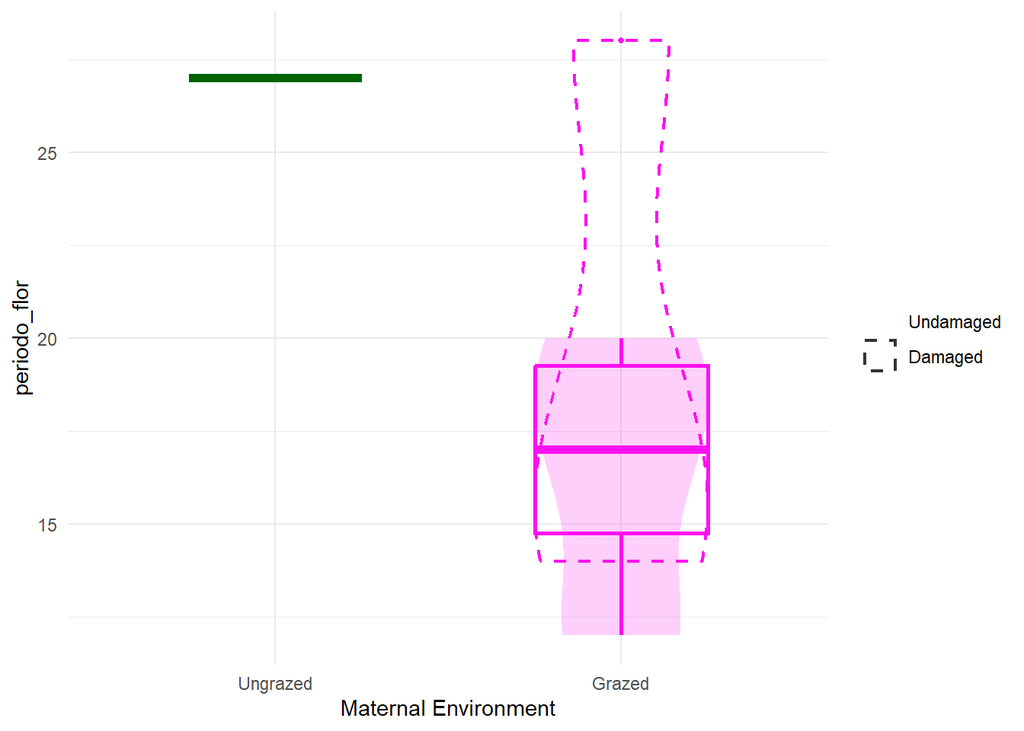

### H.murinum - PERIODO DE FRUCTIFICACIÓN

**periodo_fruto ~ trat + clip + trat:clip**

n = **8**

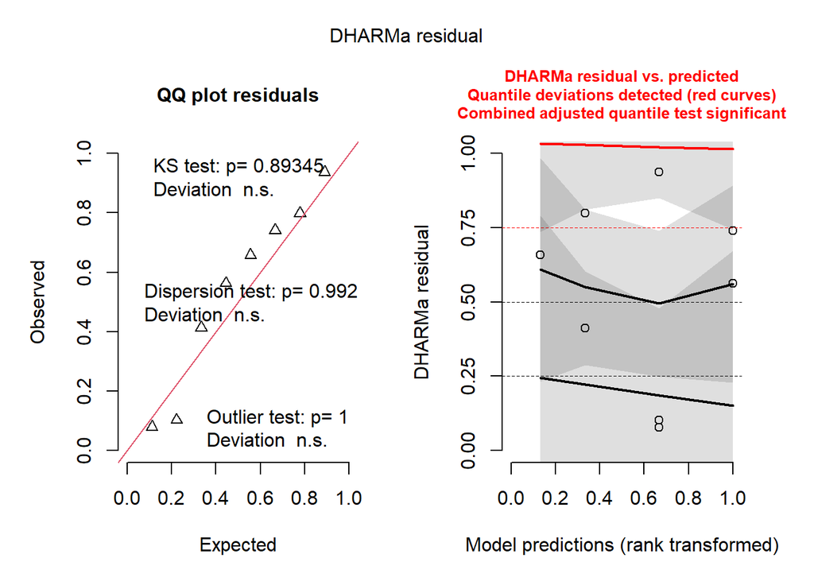

##### HOperiodo_fruto Post-hoc Comparisons with Tukeys HSD

| contrast | trat | estimate | SE | df | z.ratio | p.value |
| --- | --- | --- | --- | --- | --- | --- |
| no - yes | ex | 1.098618 | 1.657351 | Inf | 0.6628756 | 0.5074102 |
| no - yes | gra | -0.182316 | 1.227687 | Inf | -0.1485037 | 0.8819453 |

| contrast | clip | estimate | SE | df | z.ratio | p.value |
| --- | --- | --- | --- | --- | --- | --- |
| ex - gra | no | 0.6523226 | 1.339711 | Inf | 0.4869127 | 0.6263202 |
| ex - gra | yes | -0.6286110 | 1.568184 | Inf | -0.4008528 | 0.6885285 |

ANOVA Results for HOperiodo_fruto Model

| Response | Predictor | Chisq | Df | Pr(>Chisq) |
| --- | --- | --- | --- | --- |
| HO periodo_fruto | trat | 0.012 | 1 | 0.913 |
| HO periodo_fruto | clip | 0.076 | 1 | 0.783 |
| HO periodo_fruto | trat:clip | 0.386 | 1 | 0.535 |

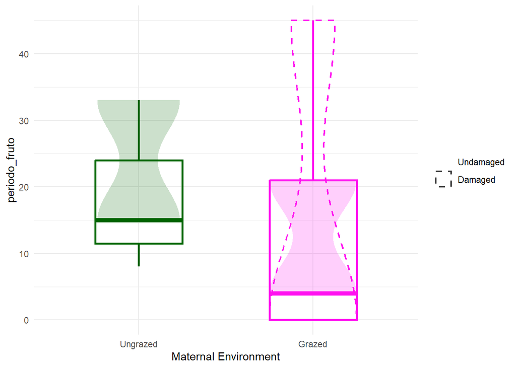

### H. murinum - dias_fin DE FLORACIÓN

**dias_fin_flor ~ trat + clip + trat:clip**  
n = **7**

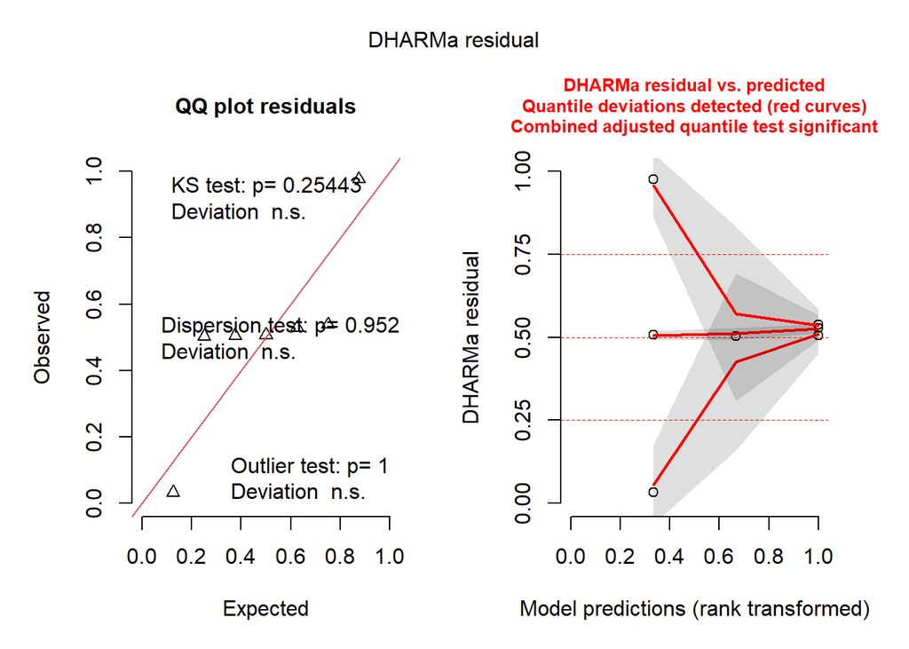

##### HOdias_fin_flor Post-hoc Comparisons with Tukeys HSD

| contrast | trat | estimate | SE | df | z.ratio | p.value |
| --- | --- | --- | --- | --- | --- | --- |
| no - yes | ex | NA | NA | NA | NA | NA |
| no - yes | gra | 0.1764906 | 0.0653827 | Inf | 2.699346 | 0.0069476 |

| contrast | clip | estimate | SE | df | z.ratio | p.value |
| --- | --- | --- | --- | --- | --- | --- |
| ex - gra | no | NA | NA | NA | NA | NA |
| ex - gra | yes | 0.1528209 | 0.091179 | Inf | 1.676054 | 0.0937277 |

ANOVA Results for HOdias_fin_flor Model

| Response | Predictor | Chisq | Df | Pr(>Chisq) |
| --- | --- | --- | --- | --- |
| HO dias_fin_flor | trat · | 2.809 | 1 | 0.094 |
| HO dias_fin_flor | clip ** | 7.286 | 1 | 0.007 |
| HO dias_fin_flor | trat:clip | NA | 0 | NA |

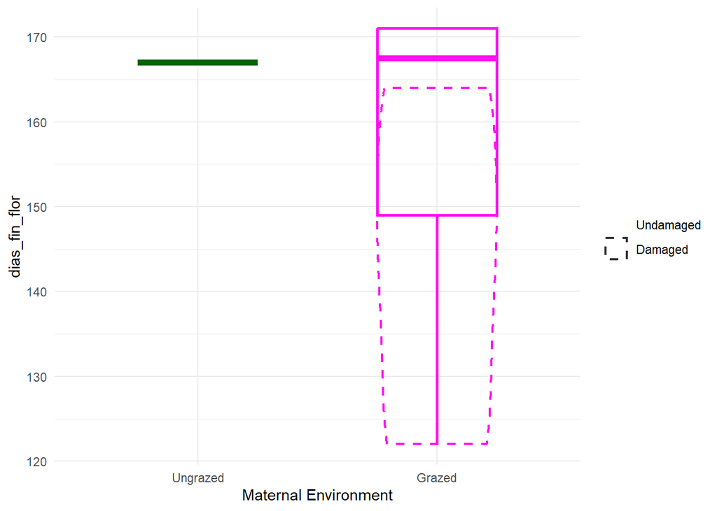

### H. murinum - dias_fin DE FRUCTIFICACIÓN

**dias_fin_fruto ~ trat + clip + trat:clip**

n = **12**

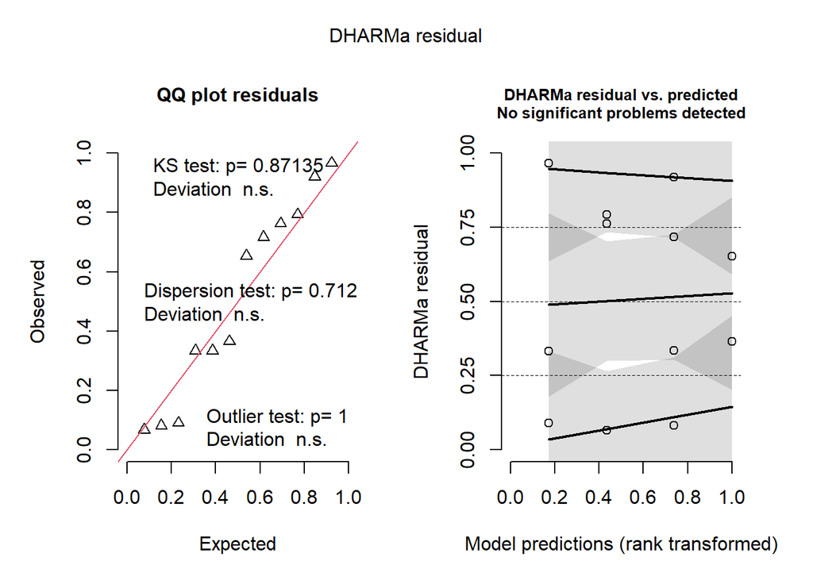

##### HOdias_fin_fruto Post-hoc Comparisons with Tukeys HSD

| contrast | trat | estimate | SE | df | z.ratio | p.value |
| --- | --- | --- | --- | --- | --- | --- |
| no - yes | ex | -0.0286679 | 0.1269157 | Inf | -0.2258812 | 0.8212938 |
| no - yes | gra | 0.1464557 | 0.1326410 | Inf | 1.1041512 | 0.2695275 |

| contrast | clip | estimate | SE | df | z.ratio | p.value |
| --- | --- | --- | --- | --- | --- | --- |
| ex - gra | no | -0.1778373 | 0.1402384 | Inf | -1.2681066 | 0.2047599 |
| ex - gra | yes | -0.0027137 | 0.1184669 | Inf | -0.0229069 | 0.9817245 |

ANOVA Results for HOdias_fin_fruto Model

| Response | Predictor | Chisq | Df | Pr(>Chisq) |
| --- | --- | --- | --- | --- |
| HO dias_fin_fruto | trat | 0.699 | 1 | 0.403 |
| HO dias_fin_fruto | clip | 0.360 | 1 | 0.548 |
| HO dias_fin_fruto | trat:clip | 0.910 | 1 | 0.340 |

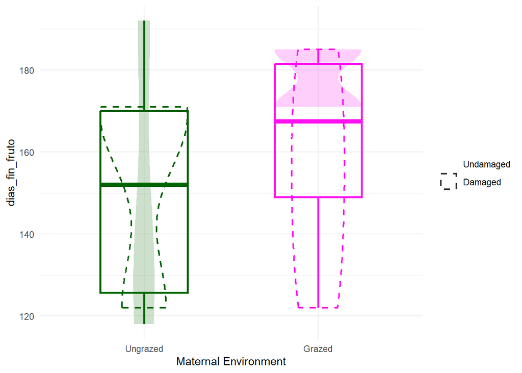

### H.murinum - ESPERANZA DE VIDA

**dias_muerte ~ trat + clip + trat:clip**  
n = **21**

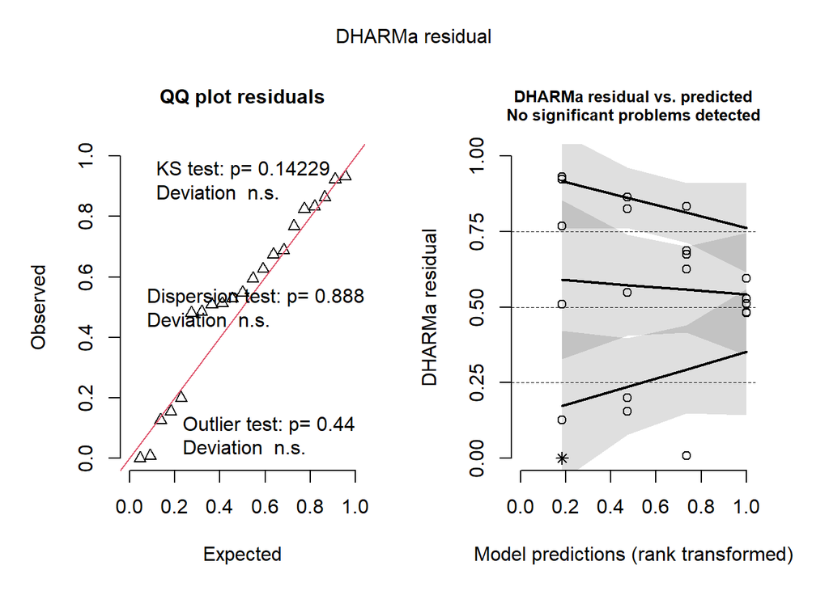

##### HOdias_muerte Post-hoc Comparisons with Tukeys HSD

| contrast | trat | estimate | SE | df | z.ratio | p.value |
| --- | --- | --- | --- | --- | --- | --- |
| no - yes | ex | -0.0520117 | 0.080220 | Inf | -0.6483641 | 0.5167495 |
| no - yes | gra | 0.0870114 | 0.083352 | Inf | 1.0439038 | 0.2965299 |

| contrast | clip | estimate | SE | df | z.ratio | p.value |
| --- | --- | --- | --- | --- | --- | --- |
| ex - gra | no | -0.1033050 | 0.0798546 | Inf | -1.2936637 | 0.1957816 |
| ex - gra | yes | 0.0357181 | 0.0837020 | Inf | 0.4267297 | 0.6695762 |

ANOVA Results for HOdias_muerte Model

| Response | Predictor | Chisq | Df | Pr(>Chisq) |
| --- | --- | --- | --- | --- |
| HO dias_muerte | trat | 0.411 | 1 | 0.521 |
| HO dias_muerte | clip | 0.066 | 1 | 0.797 |
| HO dias_muerte | trat:clip | 1.444 | 1 | 0.229 |

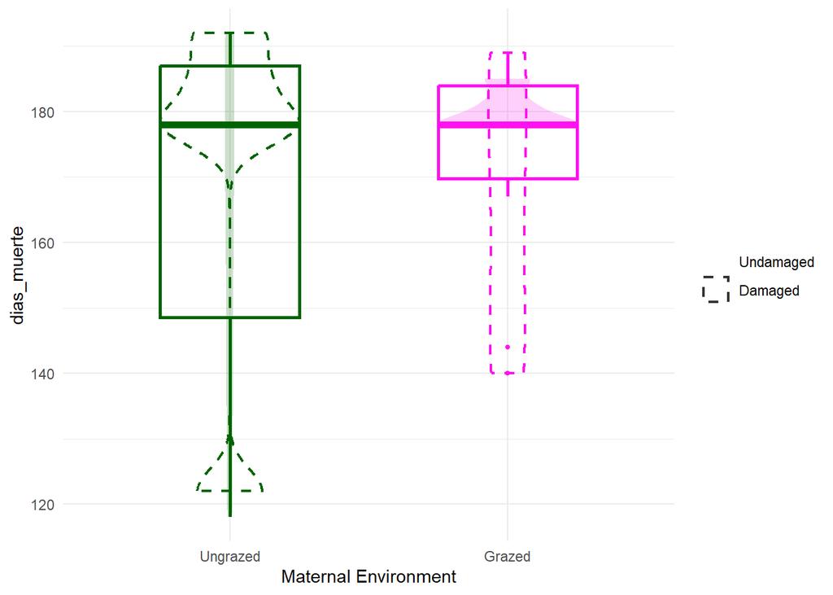

### H.murinum - FENOLES

**fenoles ~ trat + clip + trat:clip**  
n = **40** he quitado dos outliers que supongo se deben a algún error (¿3 y 170?)

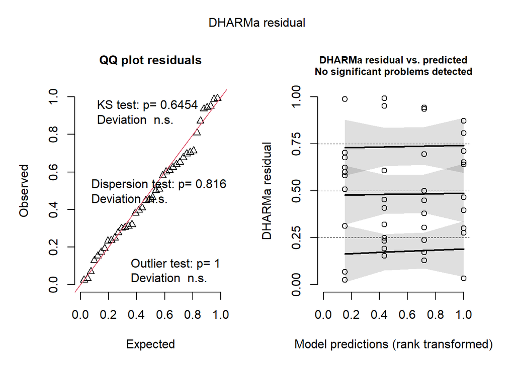

R² = **0.0819845**

##### HOfenoles Post-hoc Comparisons with Tukeys HSD

| contrast | trat | estimate | SE | df | t.ratio | p.value |
| --- | --- | --- | --- | --- | --- | --- |
| no - yes | ex | 2.9259 | 2.348641 | 36 | 1.245784 | 0.2208907 |
| no - yes | gra | 4.4731 | 2.348641 | 36 | 1.904548 | 0.0648535 |

| contrast | clip | estimate | SE | df | t.ratio | p.value |
| --- | --- | --- | --- | --- | --- | --- |
| ex - gra | no | 1.1226 | 2.348641 | 36 | 0.4779785 | 0.6355553 |
| ex - gra | yes | 2.6698 | 2.348641 | 36 | 1.1367423 | 0.2631563 |

ANOVA Results for HOfenoles Model

| Response | Predictor | Sum Sq | Df | F value | Pr(>F) |
| --- | --- | --- | --- | --- | --- |
| HO fenoles | trat | 35.956 | 1 | 1.304 | 0.261 |
| HO fenoles | clip * | 136.863 | 1 | 4.962 | 0.032 |
| HO fenoles | trat:clip | 5.985 | 1 | 0.217 | 0.644 |
| HO fenoles | Residuals | 992.901 | 36 | NA | NA |

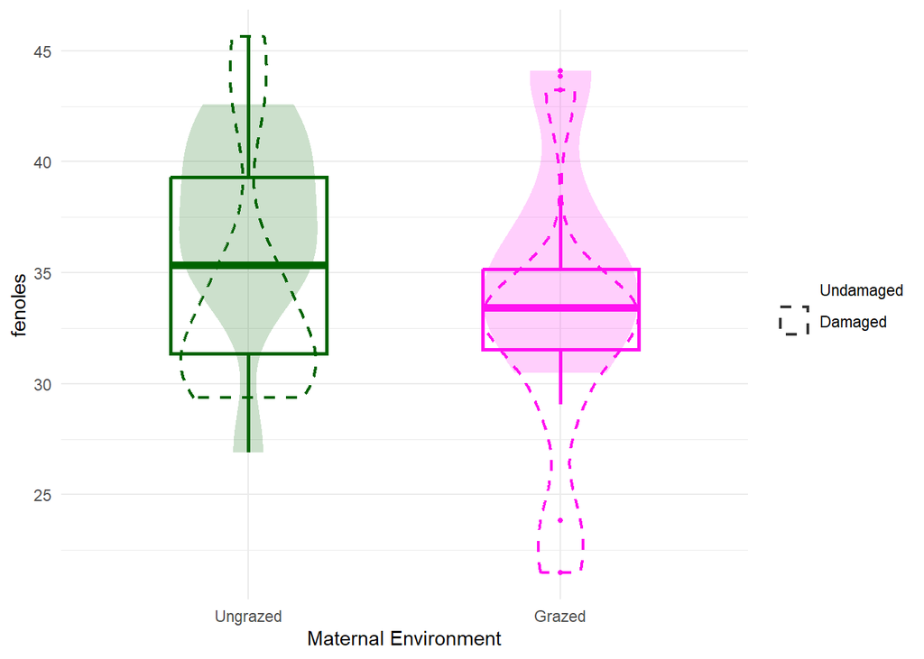

### H. murinum - BIOMASA

**biomass ~ trat + clip + trat:clip**  
n = **62**

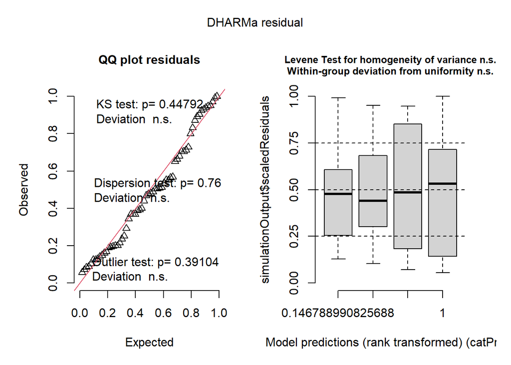

R² = **0.0891745**

##### HObiomass Post-hoc Comparisons with Tukeys HSD

| contrast | trat | estimate | SE | df | t.ratio | p.value |
| --- | --- | --- | --- | --- | --- | --- |
| no - yes | ex | 0.2800000 | 0.2607416 | 58 | 1.0738602 | 0.2873328 |
| no - yes | gra | 0.2594667 | 0.2692927 | 58 | 0.9635116 | 0.3392910 |

| contrast | clip | estimate | SE | df | t.ratio | p.value |
| --- | --- | --- | --- | --- | --- | --- |
| ex - gra | no | 0.5022458 | 0.2650516 | 58 | 1.894898 | 0.0630941 |
| ex - gra | yes | 0.4817125 | 0.2650516 | 58 | 1.817429 | 0.0743181 |

ANOVA Results for HObiomass Model

| Response | Predictor | Sum Sq | Df | F value | Pr(>F) |
| --- | --- | --- | --- | --- | --- |
| HO biomass | trat * | 3.748 | 1 | 6.891 | 0.011 |
| HO biomass | clip | 1.130 | 1 | 2.079 | 0.155 |
| HO biomass | trat:clip | 0.002 | 1 | 0.003 | 0.957 |
| HO biomass | Residuals | 31.546 | 58 | NA | NA |

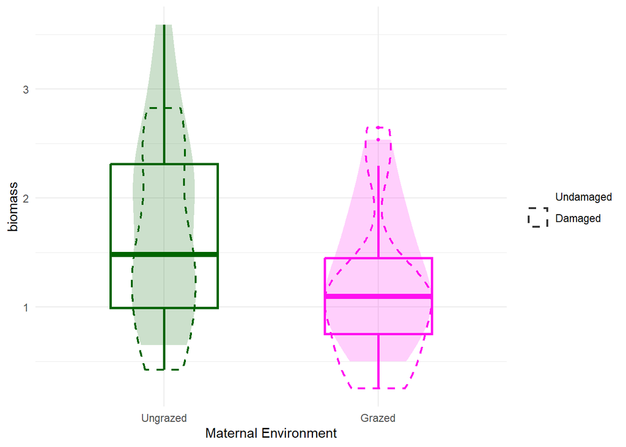

### H. murinum - Diámetro de la raíz

**AvgDiam.mm. ~ trat + clip + trat:clip**  
n = **41**

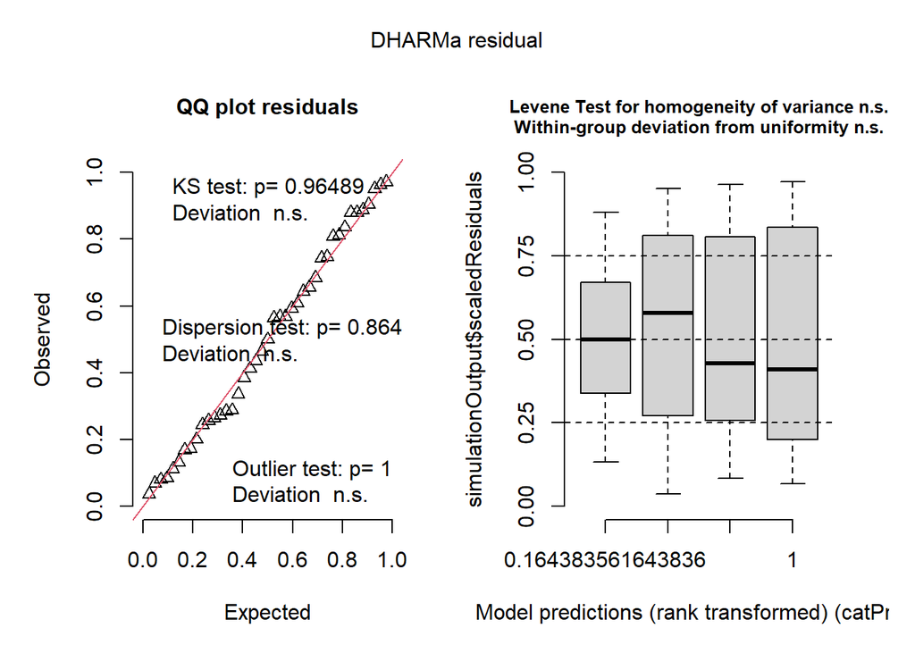

R² = **0.0760232**

##### HOAvgDiam.mm. Post-hoc Comparisons with Tukeys HSD

| contrast | trat | estimate | SE | df | t.ratio | p.value |
| --- | --- | --- | --- | --- | --- | --- |
| no - yes | ex | 0.0427155 | 0.0266541 | 37 | 1.602585 | 0.1175303 |
| no - yes | gra | 0.0402800 | 0.0272813 | 37 | 1.476468 | 0.1482795 |

| contrast | clip | estimate | SE | df | t.ratio | p.value |
| --- | --- | --- | --- | --- | --- | --- |
| ex - gra | no | -0.0214400 | 0.0272813 | 37 | -0.7858854 | 0.4369388 |
| ex - gra | yes | -0.0238755 | 0.0266541 | 37 | -0.8957520 | 0.3761761 |

ANOVA Results for HOAvgDiam.mm. Model

| Response | Predictor | Sum Sq | Df | F value | Pr(>F) |
| --- | --- | --- | --- | --- | --- |
| HO AvgDiam.mm. | trat | 0.005 | 1 | 1.416 | 0.242 |
| HO AvgDiam.mm. | clip * | 0.018 | 1 | 4.744 | 0.036 |
| HO AvgDiam.mm. | trat:clip | 0.000 | 1 | 0.004 | 0.949 |
| HO AvgDiam.mm. | Residuals | 0.138 | 37 | NA | NA |

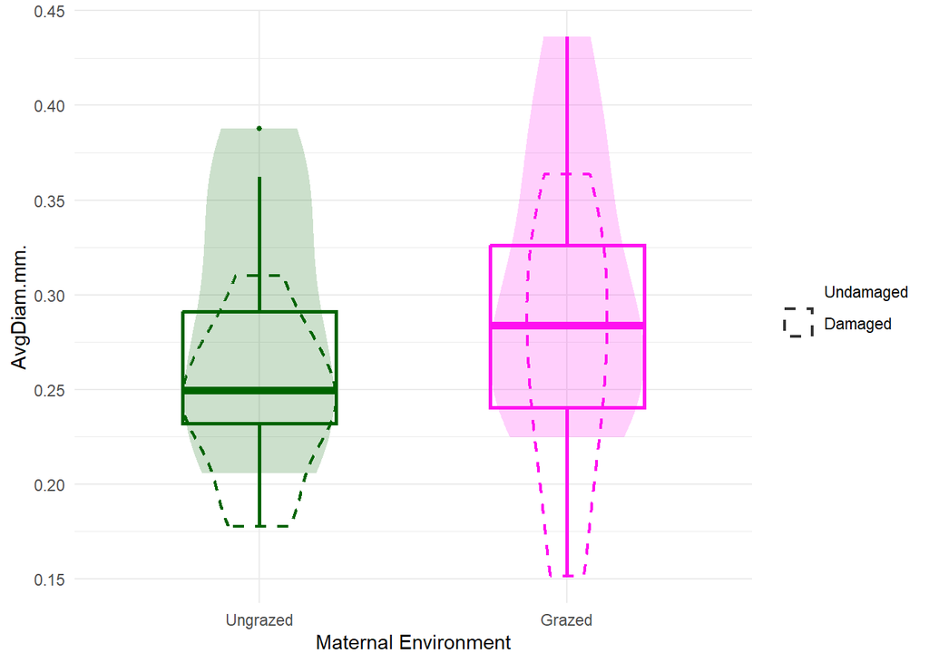

### H. murinum - Root Tissue Density (RTD)

**RTD ~ trat + clip + trat:clip**  
n = **40**

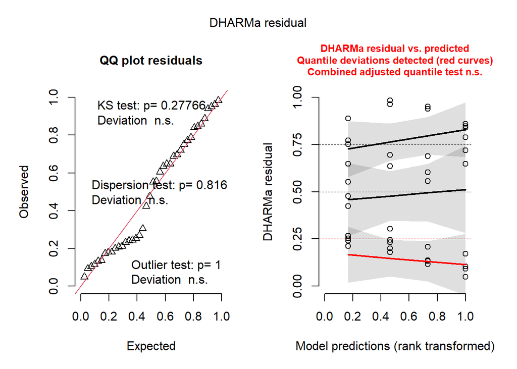

R² = **0.0206589**

##### HORTD Post-hoc Comparisons with Tukeys HSD

| contrast | trat | estimate | SE | df | t.ratio | p.value |
| --- | --- | --- | --- | --- | --- | --- |
| no - yes | ex | 0.0280964 | 0.0477823 | 36 | 0.5880087 | 0.5601973 |
| no - yes | gra | -0.0117425 | 0.0502469 | 36 | -0.2336954 | 0.8165453 |

| contrast | clip | estimate | SE | df | t.ratio | p.value |
| --- | --- | --- | --- | --- | --- | --- |
| ex - gra | no | -0.0431583 | 0.0502469 | 36 | -0.8589247 | 0.3960653 |
| ex - gra | yes | -0.0829972 | 0.0477823 | 36 | -1.7369860 | 0.0909403 |

ANOVA Results for HORTD Model

| Response | Predictor | Sum Sq | Df | F value | Pr(>F) |
| --- | --- | --- | --- | --- | --- |
| HO RTD | trat · | 0.041 | 1 | 3.425 | 0.072 |
| HO RTD | clip | 0.001 | 1 | 0.070 | 0.792 |
| HO RTD | trat:clip | 0.004 | 1 | 0.330 | 0.569 |
| HO RTD | Residuals | 0.431 | 36 | NA | NA |

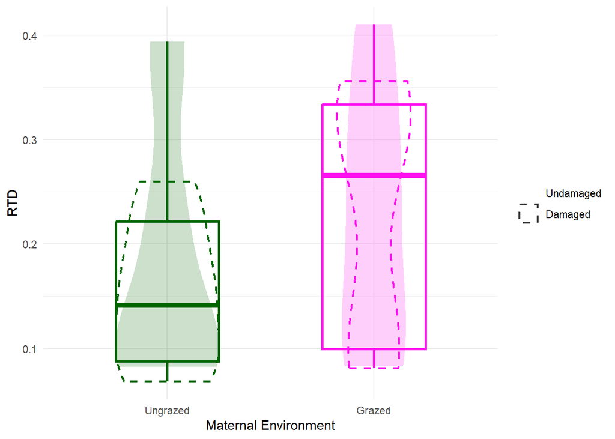

### H. murinum - Specific Root Length (SRL)

**SRL ~ trat + clip + trat:clip**  
n = **40**

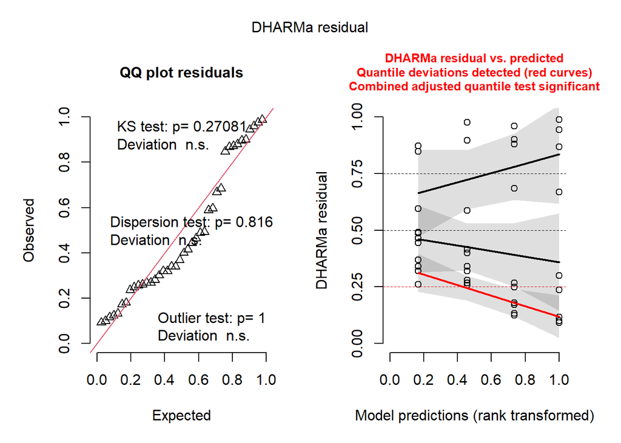

R² = **0.0975464**

##### HOSRL Post-hoc Comparisons with Tukeys HSD

| contrast | trat | estimate | SE | df | t.ratio | p.value |
| --- | --- | --- | --- | --- | --- | --- |
| no - yes | ex | 0.0054285 | 0.0082177 | 36 | 0.6605837 | 0.5130845 |
| no - yes | gra | 0.0092635 | 0.0086416 | 36 | 1.0719748 | 0.2908653 |

| contrast | clip | estimate | SE | df | t.ratio | p.value |
| --- | --- | --- | --- | --- | --- | --- |
| ex - gra | no | -0.0161618 | 0.0086416 | 36 | -1.870244 | 0.0695982 |
| ex - gra | yes | -0.0123268 | 0.0082177 | 36 | -1.500028 | 0.1423271 |

ANOVA Results for HOSRL Model

| Response | Predictor | Sum Sq | Df | F value | Pr(>F) |
| --- | --- | --- | --- | --- | --- |
| HO SRL | trat * | 0.002 | 1 | 5.644 | 0.023 |
| HO SRL | clip | 0.001 | 1 | 1.482 | 0.231 |
| HO SRL | trat:clip | 0.000 | 1 | 0.103 | 0.750 |
| HO SRL | Residuals | 0.013 | 36 | NA | NA |

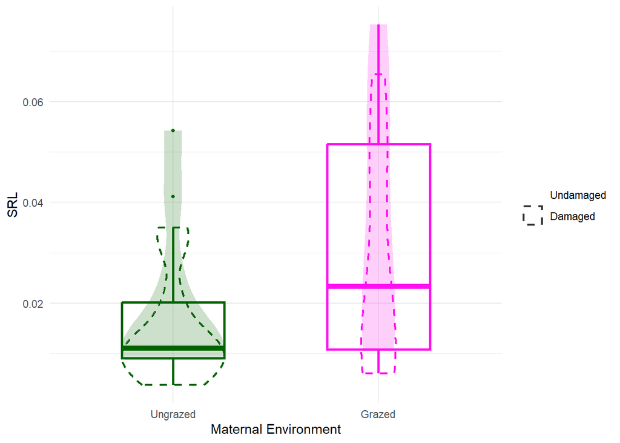